# 1. What is cross-validation? Explain everything in detail about how the cross validation can be performed on given dataset[10 pts]

Cross-validation is a statistical technique used to estimate the skill of machine learning models. In machine learning, we cannot fit the model on training data and say that the model will work accurately for the real-time data. For this, we must ensure that the model gets correct patterns from the data, and it is not adding too much noise. For this purpose, we use the cross-validation technique. It is a popular method because it is simple to understand and because it generally results in a less biased or less optimistic estimate of the model skill than other methods, such as a simple train/test split. It is easy to understand, easy to implement, and results in skill estimates that generally have a lower bias than other methods.

The three steps involved in cross-validation are as follows : 1) Reserve some portion of sample data-set for testing. 2) Using the rest data-set to train the model. 3) Test the model using the reserve portion of the data-set i.e test data set.

Methods of Cross Validation:-

LOOCV (Leave One Out Cross Validation):-

```
In this method, we perform training on the whole data-set but leaves only one data-point of the available data-set and then iterates for each data-point. It has some advantages as well as disadvantages also.
An advantage of using this method is that we make use of all data points and hence it is low bias.
The major drawback of this method is that it leads to higher variation in the testing model as we are testing against one data point. If the data point is an outlier it can lead to higher variation. Another drawback is it takes a lot of execution time as it iterates over ‘the number of data points’ times.
```

k-Fold Cross-Validation:-

```
Cross-validation is a resampling procedure used to evaluate machine learning models on a limited data sample.The procedure has a single parameter called k that refers to the number of groups that a given data sample is to be split into. The procedure is often called k-fold cross-validation. When a specific value for k is chosen, it may be used in place of k in the reference to the model, such as k=10 becoming 10-fold cross-validation.
```

The general procedure is as follows:

1) Shuffle the dataset randomly. 2) Split the dataset into k groups 3) For each unique group:

```
- Take the group as a hold out or test data set
- Take the remaining groups as a training data set
- Fit a model on the training set and evaluate it on the test set
- Retain the evaluation score and discard the model
- Summarize the skill of the model using the sample of model evaluation scores
```

Each sample is given the opportunity to be used in the hold out set 1 time and used to train the model k-1 times.

Configuration of k:-

```
The k value must be chosen carefully for your data sample. A poorly chosen value for k may result in a mis-representative idea of the skill of the model, such as a score with a high variance (that may change a lot based on the data used to fit the model), or a high bias, (such as an overestimate of the skill of the model).
```

Three common tactics for choosing a value for k are as follows:-

- Representative: The value for k is chosen such that each train/test group of data samples is large enough to be statistically representative of the broader dataset.
- k=10: The value for k is fixed to 10, a value that has been found through experimentation to generally result in a model skill estimate with low bias a modest variance.
- k=n: The value for k is fixed to n, where n is the size of the dataset to give each test sample an opportunity to be used in the hold out dataset. This approach is called leave-one-out cross-validation.

The choice of k is usually 5 or 10, but there is no formal rule. As k gets larger, the difference in size between the training set and the resampling subsets gets smaller. As this difference decreases, the bias of the technique becomes smaller.

If a value for k is chosen that does not evenly split the data sample, then one group will contain a remainder of the examples. It is preferable to split the data sample into k groups with the same number of samples, such that the sample of model skill scores are all equivalent.

Variations on Cross-Validation:-

```
1) Train/Test Split: Taken to one extreme, k may be set to 2 (not 1) such that a single train/test split is created to evaluate the model.
2) LOOCV: Taken to another extreme, k may be set to the total number of observations in the dataset such that each observation is given a chance to be the held out of the dataset. This is called leave-one-out cross-validation, or LOOCV for short.
3) Stratified: The splitting of data into folds may be governed by criteria such as ensuring that each fold has the same proportion of observations with a given categorical value, such as the class outcome value. This is called stratified cross-validation.
4) Repeated: This is where the k-fold cross-validation procedure is repeated n times, where importantly, the data sample is shuffled prior to each repetition, which results in a different split of the sample.
```

Library in python supporting Cross validation implementation - scikit-learn

# 2. What are advantages and disadvantages of Cross validation? [5 Pts]

Advantages of cross-validation:-

```
1) More accurate estimate of out-of-sample accuracy.
2) More “efficient” use of data as every observation is used for both training and testing.
3) No randomness of using some observations for training vs. validation set like in validation-set method as
each observation is considered for both training and validation. So overall less variability than Validation-set
method due to no randomness.(it does not mean LOOCV does not have variability, see disadvantage no.1)
4) As validation set is larger than in LOOCV, it gives less variability in test-error as more observations are
used for each iteration’s prediction.
5) Less bias than validation-set method as training-set is larger is use 5 or more folds. Because of larger
training set reduced bias, reduced over-estimation of test-error, not as much compared to validation-set method.
6) computationally NOT expensive as LOOCV as need to run it only k times which is usually 5 or 10.
```

Disadvantages of cross-validation:-

```
1) Some what higher bias than LOOCV due to smaller training set for each iteration (but smaller bias than
    Validation-set method due to larger training set than VS.)

2) Unlike LOOCV, both cv-error numbers are slightly different. this is because first numer is standard k-fold
    CV estimate of test-MSE. the second number is bias-corrected version.
3) Computation time for k-fold CV should be shorter than LOOCV especially for large datasets. not for
least-squares regression due to the availability of the formula.
4) Comparing test-MSEs are better in case of k-fold CV than LOOCV. k-fold CV or any CV or resampling
   methods does not improve test errors. they estimate test errors. In case of k-fold, it does better job
   of estimating error than LOOCV.
```

# 3. What is Generalized Additive Models?[Please refer to our course textbook Elements of Statistical Learning Textbook for this] [5 Pts]

In the regression setting, a generalized additive model has the form

```
E(Y |X1, X2, . . . , Xp) = α + f1(X1) + f2(X2) + · · · + fp(Xp);
where X1 , X2 , . . . , Xp represent predictors and Y is the outcome
```

The additive logistic regression model

```
log(μ(X)/1−μ(X)) = α + f1(X1) + · · · + fp(Xp); where each fj is an unspecified smooth function.
```

While the non- parametric form for the functions fj makes the model more flexible, the additivity is retained and allows us to interpret the model. The additive logistic regression model is an example of a generalized additive model.

In general, the conditional mean μ(X) of a response Y is related to an additive function of the predictors via a link function g:

```
    g[μ(X)] = α + f1(X1) + · · · + fp(Xp).
```

Examples of classical link functions are the following: • g(μ) = μ is the identity link, used for linear and additive models for Gaussian response data. • g(μ) = logit(μ) as above, or g(μ) = probit(μ), the probit link function, for modeling binomial probabilities. The probit function is the inverse Gaussian cumulative distribution function: probit(μ) = Φ−1(μ). • g(μ) = log(μ) for log-linear or log-additive models for Poisson count data.

Fitting Additive Models:- The building block is the scatterplot smoother for fitting nonlinear effects in a flexible way. For concreteness we use as our scatterplot smoother the cubic smoothing spline.

The additive model has the form

```
Y =α + Sum(fj(Xj))+ε
where the error term ε has mean zero.
```

# 4. How does Decison Tree Based Method’s differ from the rest of the classification methods? [5 Pts]

Decision Trees (DTs) are a non-parametric supervised learning method used for classification and regression. The deeper the tree, the more complex the decision rules and the fitter the model.

1) One big advantage of the decision tree model is its transparent nature. Unlike other decision-making models, the decision tree makes explicit all possible alternatives and traces each alternative to its conclusion in a single view, allowing for easy comparison among the various alternatives. The use of separate nodes to denote user defined decisions, uncertainties, and end of process lends further clarity and transparency to the decision-making process.

2) A decision tree also allows for partitioning data in a much deeper level, not as easily achieved with other decision-making classifiers such as logistic regression or support of vector machines.

3) Decision trees also allow for classification of data without computation, can handle both continuous and categorical variables, and provide a clear indication of the most important fields for prediction or classification, all unmatched features when comparing this model to other compatible models such as support vector or logistic regression.

4) Flexibility Unlike other decision-making tools that require comprehensive quantitative data, decision trees remain flexible to handle items with a mixture of real-valued and categorical features, and items with some missing features. Once constructed, they classify new items quickly.

5) Specificity A major decision tree analysis advantages is its ability to assign specific values to problem, decisions, and outcomes of each decision. This reduces ambiguity in decision-making. Every possible scenario from a decision finds representation by a clear fork and node, enabling viewing all possible solutions clearly in a single view.

6) Comprehensive Nature The decision tree is the best predictive model as it allows for a comprehensive analysis of the consequences of each possible decision, such as what the decision leads to, whether it ends in uncertainty or a definite conclusion, or whether it leads to new issues for which the process needs repetition.

7) Validation A decision tree is the best predictive model. It finds use to make quantitative analysis of business problems, and to validate results of statistical tests. It naturally supports classification problems with more than two classes and by modification, handles regression problems.

# 5. What are different classification techniques available and How does a Decision Tress work? [Please write in atleast 5 sentences] [10 pts].

Different Classification techniques are -

```
1. Linear Discriminant Analysis (LDA)
2. K-Nearest Neighbors
3. Logistic Rgression
4. Neural Networks
5. Multivariate Discriminant Analysis
```

Working of Decision Trees :- 1) Splitting The process of partitioning the data set into subsets. Splits are formed on a particular variable.

2) Pruning The shortening of branches of the tree. Pruning is the process of reducing the size of the tree by turning some branch nodes into leaf nodes, and removing the leaf nodes under the original branch. Pruning is useful because classification trees may fit the training data well, but may do a poor job of classifying new values. A simpler tree often avoids over-fitting.

3) Tree Selection The process of finding the smallest tree that fits the data. Usually this is the tree that yields the lowest cross-validated error.

```
Entropy:-
```

A decision tree is built top-down from a root node and involves partitioning the data into subsets that contain instances with similar values (homogeneous). ID 3 algorithm uses entropy to calculate the homogeneity of a sample. If the sample is completely homogeneous the entropy is zero and if the sample is an equally divided it has entropy of one.

```
Information Gain:-
```

The information gain is based on the decrease in entropy after a dataset is split on an attribute. Constructing a decision tree is all about finding attribute that returns the highest information gain (i.e., the most homogeneous branches).

Step 1: Calculate entropy of the target. Step 2: The dataset is then split on the different attributes. The entropy for each branch is calculated. Then it is added proportionally, to get total entropy for the split. The resulting entropy is subtracted from the entropy before the split. The result is the Information Gain, or decrease in entropy. Step 3: Choose attribute with the largest information gain as the decision node, divide the dataset by its branches and repeat the same process on every branch.

# 6. What are some of the advantages and disadvantages of decision trees? [5 pts]

Advantages:-

```
1) Compared to other algorithms decision trees requires less effort for data preparation during pre-processing.
2) A decision tree does not require scaling of data as well.
3) Missing values in the data also does NOT affect the process of building decision tree to
    any considerable extent.
4) Computionally cheap to use, easy for humans to understand results.
5) Interpretation of a complex Decision Tree model can be simplified by its visualizations. Even a naive person can understand logic. The Number of hyper-parameters to be tuned is almost null.
```

Disadvantages:

```
1) There is a high probability of overfitting in Decision Tree.
2) A small change in the data can cause a large change in the structure of the decision tree causing instability.
3) For a Decision tree sometimes calculation can go far more complex compared to other algorithms.
4) Decision tree often involves higher time to train the model.
5) Decision tree training is relatively expensive as complexity and time taken is more.
6) Decision Tree algorithm is inadequate for applying regression and predicting continuous values.
7) Information gain in a decision tree with categorical variables gives a biased response for attributes with greater no. of categories.
```

# 7. What are different subset selection based methods and explain the difference between subset selection based method’s vs cross validation [Explain with example] [10 Pts]

Subset selection Methods:-

```
1. Best Subset Selection -
```

The regsubsets() function (part of the leaps library) performs best sub- set selection by identifying the best model that contains a given number of predictors, where best is quantified using RSS. The summary() command outputs the best set of variables for each model size. The summary() function also returns R2, RSS, adjusted R2, Cp, and BIC. We can examine these to try to select the best overall model.

```
2. Forward and Backward stepwise selection -
```

We can also use the regsubsets() function to perform forward stepwise or backward stepwise selection, using the argument method=“forward” or method=“backward”.

```
3. Choosing Among Models Using the Validation Set Approach -
```

We will now consider how to do this using the validation set and cross-validation approaches.

In order for these approaches to yield accurate estimates of the test error, we must use only the training observations to perform all aspects of model-fitting, including variable selection.

Therefore, the determination of which model of a given size is best must be made using only the training observations.

```
4. Choosing Among Models Using the Cross-Validation Approach -
```

choose among the models of different sizes using cross- validation. This approach is somewhat involved, as we must perform best subset selection within each of the k training sets.

# 8. Please Perform Logistic Classification on the Give dataset (insurance-data.csv) be- low.[10 Points] Dataset Link : Dataset 10 Points for Logistic Regression accuracy and output plots.

```python
import pandas as pd

# Read insurance_data csv file
insuranceData = pd.read_csv('insurance_data.csv')
print(insuranceData.head())
print(insuranceData.describe())
```

```
   age  bought_insurance
0   22                 0
1   25                 0
2   47                 1
3   52                 0
4   46                 1
             age  bought_insurance
count  27.000000         27.000000
mean   39.666667          0.518519
std    15.745573          0.509175
min    18.000000          0.000000
25%    25.000000          0.000000
50%    45.000000          1.000000
75%    54.500000          1.000000
max    62.000000          1.000000
```

```python
# Divide dataset into descriptive features and target features
X = insuranceData.iloc[:, :-1].values
Y = insuranceData.iloc[:, 1].values

# Split dataset to training and testing dataset
from sklearn.model_selection import train_test_split
X_train, X_test, Y_train, Y_test = train_test_split(X, Y, test_size=0.25, random_state=10)
```

```python
from sklearn.linear_model import LogisticRegression

#Apply . Logistic Regression model to Training dataset
logreg = LogisticRegression()
logreg.fit(X_train, Y_train)
```

```
LogisticRegression()
```

```python
# Predict on test dataset and get accuracy Score
y_pred = logreg.predict(X_test)
print('Accuracy of logistic regression classifier on test set: ', format(logreg.score(X_test, Y_test)))
```

```
Accuracy of logistic regression classifier on test set:  1.0
```

```python
# Evaluating model, Confusion Matrix
from sklearn import metrics
cnf_matrix = metrics.confusion_matrix(Y_test, y_pred)
cnf_matrix
```

```
array([[4, 0],
       [0, 3]])
```

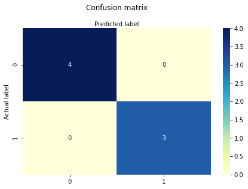

```python
import numpy as np
import matplotlib.pyplot as plt
import seaborn as sns
%matplotlib inline


class_names=[0,1] # name  of classes
fig, ax = plt.subplots()
tick_marks = np.arange(len(class_names))
plt.xticks(tick_marks, class_names)
plt.yticks(tick_marks, class_names)

# create heatmap
sns.heatmap(pd.DataFrame(cnf_matrix), annot=True, cmap="YlGnBu" ,fmt='g')
ax.xaxis.set_label_position("top")
plt.tight_layout()
plt.title('Confusion matrix', y=1.1)
plt.ylabel('Actual label')
plt.xlabel('Predicted label')
```

```python
print("Accuracy:",metrics.accuracy_score(Y_test, y_pred))
print("Precision:",metrics.precision_score(Y_test, y_pred))
print("Recall:",metrics.recall_score(Y_test, y_pred))
```

```
Accuracy: 1.0
Precision: 1.0
Recall: 1.0
```

# 9. Please Perform Decision Tree Classification on the Give dataset(data.csv) below.[40 Points]

Dataset Link : Dataset 15 Points for Data Preprocessing. 15 Points for Decision Tree along with Tree Plot at the end and Results Explanation. 10 Points for applying the crossvalidation on the given data and show all the accuraies for each split. Please do mention what is the best model to use. Hints: As per the data preprocessing step convert all the variables in the dataset into Numerical values as the algorithms only work with Numerical values

```python
import pandas as pd
from sklearn.model_selection import train_test_split
from sklearn import preprocessing
from sklearn import tree
from sklearn import datasets, linear_model


# Loading Data
dataDf = pd.read_csv('data.csv')

print(dataDf.head())
print("Data Shape=", dataDf.shape)
```

```
   acousticness  danceability  duration_ms  energy  instrumentalness  key  \
0        0.0102         0.833       204600   0.434          0.021900    2
1        0.1990         0.743       326933   0.359          0.006110    1
2        0.0344         0.838       185707   0.412          0.000234    2
3        0.6040         0.494       199413   0.338          0.510000    5
4        0.1800         0.678       392893   0.561          0.512000    5

   liveness  loudness  mode  speechiness    tempo  time_signature  valence  \
0    0.1650    -8.795     1       0.4310  150.062               4    0.286
1    0.1370   -10.401     1       0.0794  160.083               4    0.588
2    0.1590    -7.148     1       0.2890   75.044               4    0.173
3    0.0922   -15.236     1       0.0261   86.468               4    0.230
4    0.4390   -11.648     0       0.0694  174.004               4    0.904

       song_title            artist  target
0        Mask Off            Future       1
1         Redbone  Childish Gambino       1
2    Xanny Family            Future       1
3  Master Of None       Beach House       1
4  Parallel Lines       Junior Boys       1
Data Shape= (2017, 16)
```

```python
dataDfTemp = dataDf.iloc[:, :16]

# Data preprocessing
le = preprocessing.LabelEncoder()
for column_name in dataDf.columns:
    if dataDf[column_name].dtype == object:
        dataDf[column_name] = le.fit_transform(dataDf[column_name])

# Normalizing data with min-max normalization
x = dataDf.iloc[:, :16].values
min_max_scaler = preprocessing.MinMaxScaler(feature_range=[0, 3]) # normalization range [0,3]
x_scaled = min_max_scaler.fit_transform(x)
dataNormalizedDf = pd.DataFrame(x_scaled, columns=dataDfTemp.columns)
```

```python
X = dataNormalizedDf.iloc[:, :-1].values
y = dataNormalizedDf['target'].values

# Applying Stratified sampling
X_train, X_test, y_train, y_test = train_test_split(X, y, test_size=0.33, random_state=0, stratify=y)
print("Shape after split::", X_train.shape, X_test.shape, y_train.shape, y_test.shape)

# fit a model using Linear Regression
lm = linear_model.LinearRegression()
model = lm.fit(X_train, y_train)
predictions = lm.predict(X_test)

# Decision Tree with Entropy
dct = tree.DecisionTreeClassifier(criterion='entropy', max_depth=4, random_state=0)
dct = dct.fit(X_train, y_train)
scoreTrain =dct.score(X_train, y_train)
scoreTest = dct.score(X_test, y_test)
print("scoreTrain=", scoreTrain)
print("scoreTest=", scoreTest)
```

```
Shape after split:: (1351, 15) (666, 15) (1351,) (666,)
scoreTrain= 0.7623982235381199
scoreTest= 0.7027027027027027
```

```python
tree.export_graphviz(dct, out_file='dct_entropy.dot')
```

```python
# Used below command from terminal to generate tree.png file of Decision Tree
#dot -Tpng dct_entropy.dot -o tree_dct.png
```

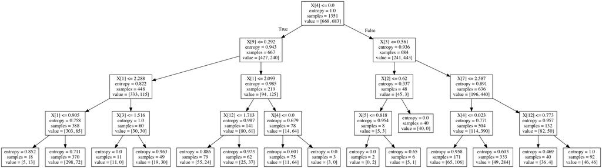

```python
from IPython.display import Image
Image("tree_dct.png")
```

```
    LevelLimit  Score for Training  Score for Testing
1          1.0            0.643967           0.639640
2          2.0            0.698001           0.707207
3          3.0            0.735751           0.723724
4          4.0            0.762398           0.702703
5          5.0            0.792746           0.732733
6          6.0            0.820133           0.705706
7          7.0            0.846780           0.681682
8          8.0            0.875648           0.695195
9          9.0            0.912657           0.701201
10        10.0            0.934123           0.699700
    LevelLimit  Score for Training  Score for Testing
1          1.0            0.643967           0.639640
2          2.0            0.698001           0.707207
3          3.0            0.735751           0.723724
4          4.0            0.762398           0.702703
5          5.0            0.793486           0.728228
6          6.0            0.833457           0.683183
7          7.0            0.862324           0.675676
8          8.0            0.888971           0.671171
9          9.0            0.916358           0.656156
10        10.0            0.931162           0.668168
```

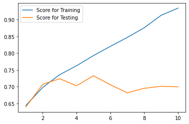

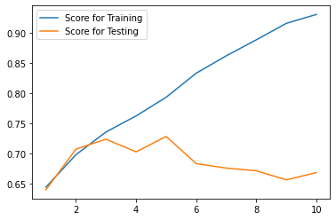

```python
# Entropy with different depths from 1 to 10
resultsEntropy = pd.DataFrame(columns=['LevelLimit', 'Score for Training', 'Score for Testing'])
for treeDepth in range (1, 11):
    dct = tree.DecisionTreeClassifier(criterion='entropy', max_depth=treeDepth, random_state=0)
    dct = dct.fit(X_train, y_train)
    dct.predict(X_test)
    scoreTrain =dct.score(X_train, y_train)
    scoreTest = dct.score(X_test, y_test)
    resultsEntropy.loc[treeDepth] = [treeDepth, scoreTrain, scoreTest]

print(resultsEntropy.head(11))
resultsEntropy.pop('LevelLimit')
ax = resultsEntropy.plot()

# Gini index
resultsGini = pd.DataFrame(columns=['LevelLimit', 'Score for Training', 'Score for Testing'])
for treeDepth in range (1, 11):
    dct = tree.DecisionTreeClassifier(criterion='gini', max_depth=treeDepth, random_state=50)
    dct = dct.fit(X_train, y_train)
    dct.predict(X_test)
    scoreTrain =dct.score(X_train, y_train)
    scoreTest = dct.score(X_test, y_test)
    resultsGini.loc[treeDepth] = [treeDepth, scoreTrain, scoreTest]

print(resultsGini.head(11))
resultsGini.pop('LevelLimit')
ax = resultsGini.plot()
plt.show()
```

```python
# Cross Validation

# K-fold
from sklearn.model_selection import KFold # import KFold

kf = KFold(n_splits=2) # Define the split - into 2 folds
kf.get_n_splits(X) # returns the number of splitting iterations in the cross-validator
print(kf)
```

```
KFold(n_splits=2, random_state=None, shuffle=False)
```

```python
for train_index, test_index in kf.split(X):
    print("TRAIN:", train_index, "TEST:", test_index)
```

```
TRAIN: [1009 1010 1011 ... 2014 2015 2016] TEST: [   0    1    2 ... 1006 1007 1008]
TRAIN: [   0    1    2 ... 1006 1007 1008] TEST: [1009 1010 1011 ... 2014 2015 2016]
```

```python
# Cross Validation LOOCV
from sklearn.model_selection import LeaveOneOut

loo = LeaveOneOut()
loo.get_n_splits(X)
for train_index, test_index in loo.split(X):
    print("TRAIN:", train_index, "TEST:", test_index)
print(X_train, X_test, y_train, y_test)
```

[output not shown]

[output cut: 2008 more lines]

[output not shown]

```python
from sklearn.model_selection import cross_val_score, cross_val_predict
from sklearn import metrics

# Perform 6-fold cross validation
scores = cross_val_score(model, X, y, cv=6)
print("Cross-validated scores:", scores)
```

```
Cross-validated scores: [ 0.          0.          0.         -8.50612188  0.          0.        ]
```